# Proyecto 2 - Reporte UFO (y un poco de GDELT)

Sergio Haro Perez

30/05/2015

National UFO Reporting Center, menciona en su pagina ser la mas comprensiva y actualizada fuente de información desde 1974. Los reportes son capturados mediantes un formulario y despues son agrupados por mes y por años, por cada mes se presenta una tabla como reporte consolidado:

- Date / Time
- City
- State
- Shape
- Duration
- Summary Posted

Cada fecha de publicación contiene un vinculo hacia el detalle del de ese dia.

| Date…Time | City | State | Shape | Duration | Summary | Posted | report |
| --- | --- | --- | --- | --- | --- | --- | --- |
| 4/23/15 12:00 | Rock Hill | SC | Rectangle | 10 minutes | Big white objects falling from the sky. | 4/23/15 | Big white objects falling from the sky.I was walking back to my dorm and looked up to see a lot of white floating objects. They were taking their time to fall, no man made aircraft flew over before th… |

Ahora las preguntas correspondientes al proyecto, son las siguientes:

- ¿Primer avistamiento en cada estado?

# 1969

  El primer avistamiento cronologico, aunque en los textos se encuentra 1762.

| state | date |
| --- | --- |
| LA | 1969-01-01 |
| NV | 1969-01-01 |
| PA | 1969-01-01 |
| FL | 1969-01-15 |
| MT | 1969-01-15 |

- ¿Primer avistamiento de cada forma?

[figure not shown]

| shape | date |
| --- | --- |
| Other | 1969-01-01 |
| Triangle | 1969-01-01 |
| Unknown | 1969-01-01 |
| Rectangle | 1969-01-15 |
| Sphere | 1969-01-15 |

- ¿Promedio de entre avistamientos, por mes, por año? (¡¡Click Sobre el grafico!!)

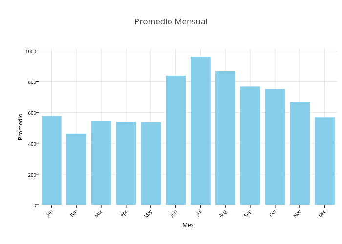

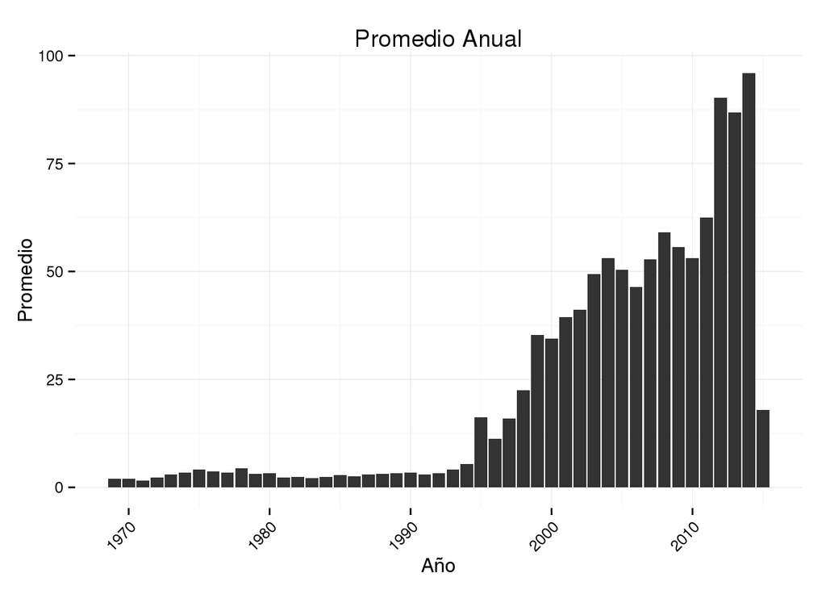

- ¿Por estado?

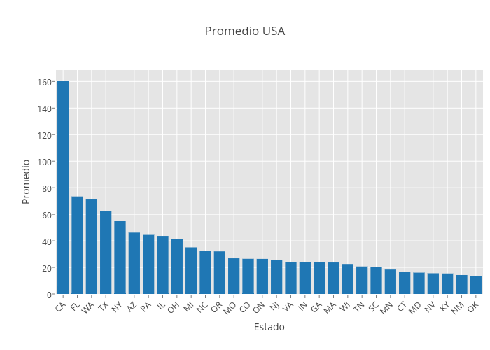

- ¿Cuál estado tiene mayor varianza?

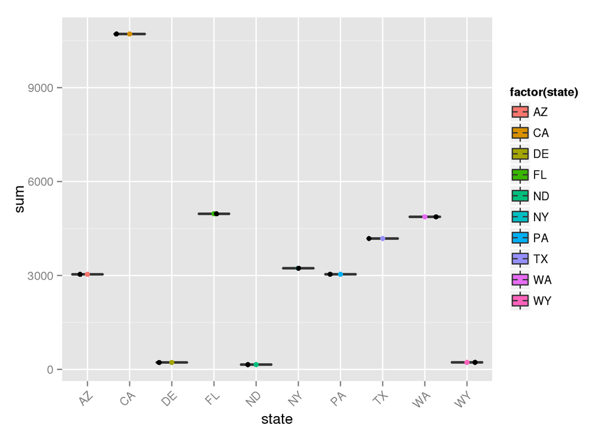

- ¿Existen olas temporales?

Podemos ver en las graficas anteriores, que existe un incremento de avistamientos en la ultima decada. Tomaremos los avistamientos de los ultimos 3 años, ya que respresentan un incremento significativo.

Podemos analizar que los meses con mayor numero de avistamientos son en los meses de Julio teniendo un decremento hasta Diciembre.

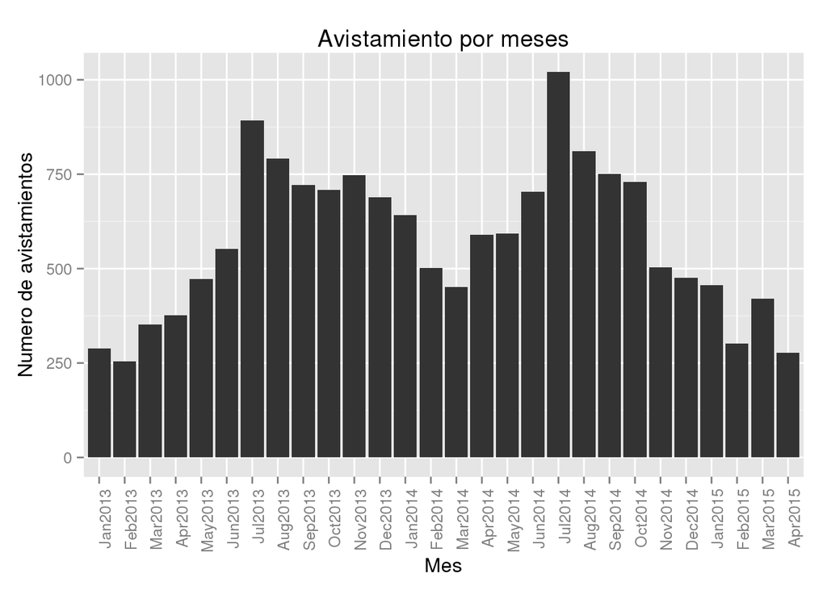

Y vemos que los dias de la semana con mas avistamientos son Sabados y Domingo…

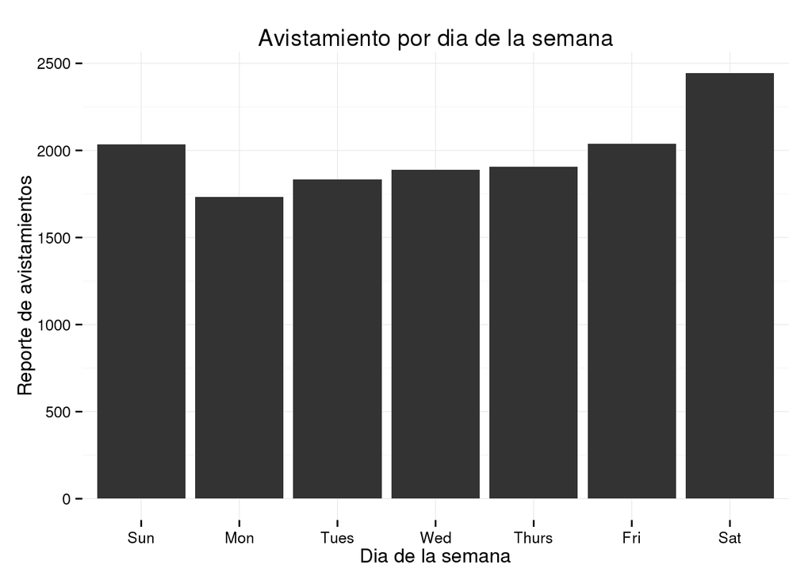

- ¿Existen olas espacio-temporales?

Analizando en el mapa, vemos que el estado con mayor numero de avistamientos es California.

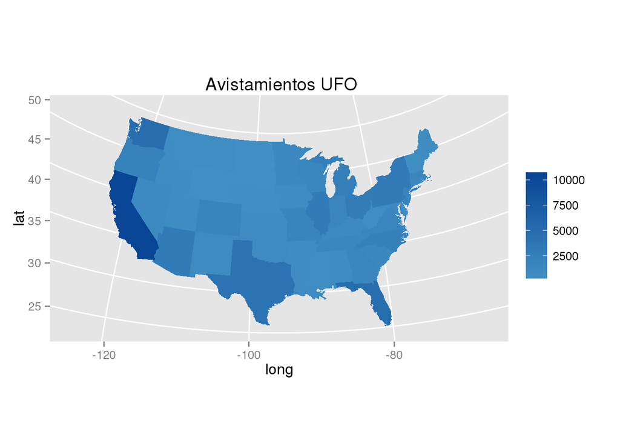

- ¿Narrativas parecidas?

De los reportes de avistamientos, podemos obtener la frecuencia de las palabras.

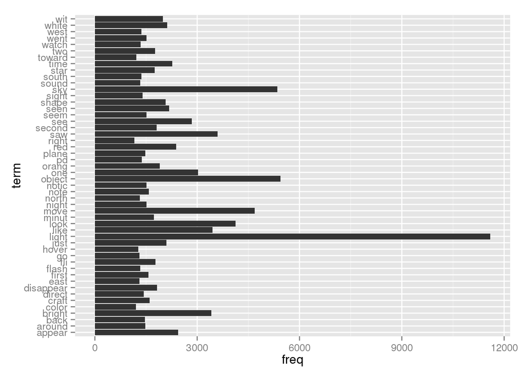

De esta palabras, podemos crear una nube con las 80 palabras mas frecuentes.

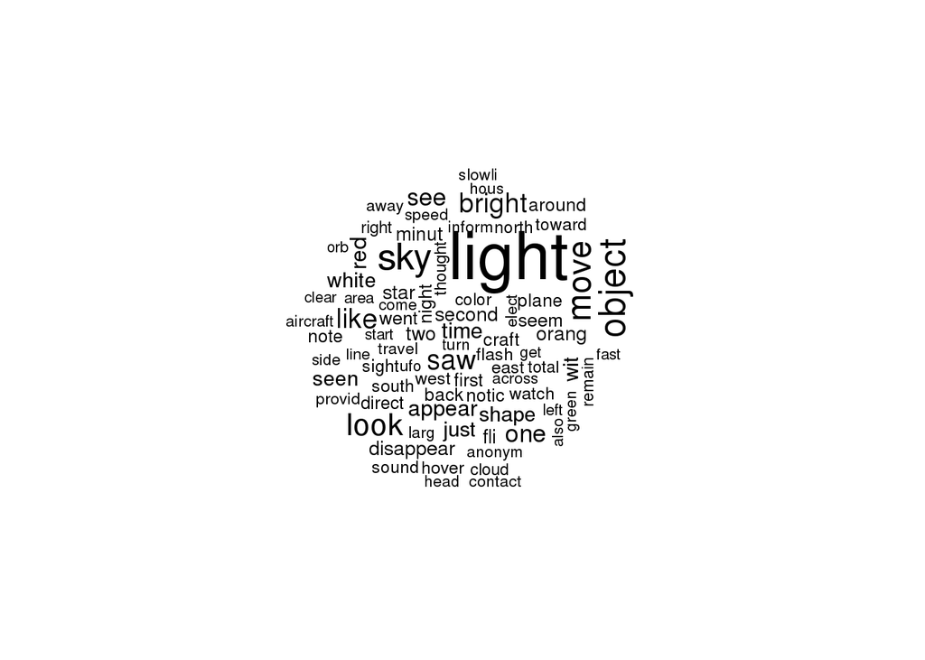

esta nube nos arroja las palabras que mas se repiten en los comentarios, mismas que podriamos buscar con que palabras se relacionan mas, esto con el objetivo de ver cual es la narrativa mas común.

Utilizando las palabras ma frecuentes. + Light + Object + Sky + Bright

podemos evaluar con que otros terminos se asocian frecuentemente.

```
##     light.see     light.one     light.red    light.time     light.two
##          0.35          0.29          0.29          0.29          0.29
##  light.appear   light.first   light.point    light.move    light.also
##          0.28          0.28          0.28          0.27          0.26
##   light.minut     light.saw  light.second   light.white    light.back
##          0.26          0.26          0.26          0.26          0.25
## object.observ object.appear object.direct    sky.across      sky.look
##          0.30          0.27          0.25          0.34          0.30
##     sky.night       sky.see      sky.move      sky.star    sky.appear
##          0.29          0.28          0.26          0.26          0.25
##     sky.clear      sky.time      sky.also      sky.like     sky.watch
##          0.25          0.25          0.24          0.23          0.23
##      sky.just     sky.point       sky.saw      sky.seem     sky.first
##          0.22          0.22          0.22          0.22          0.21
##      sky.much     sky.notic      sky.seen   bright.star
##          0.21          0.21          0.21          0.20
```

Podemos analizar que la mayor parte de las relaciones con Light, que es el termino mas frecuente se da con + see + one + red

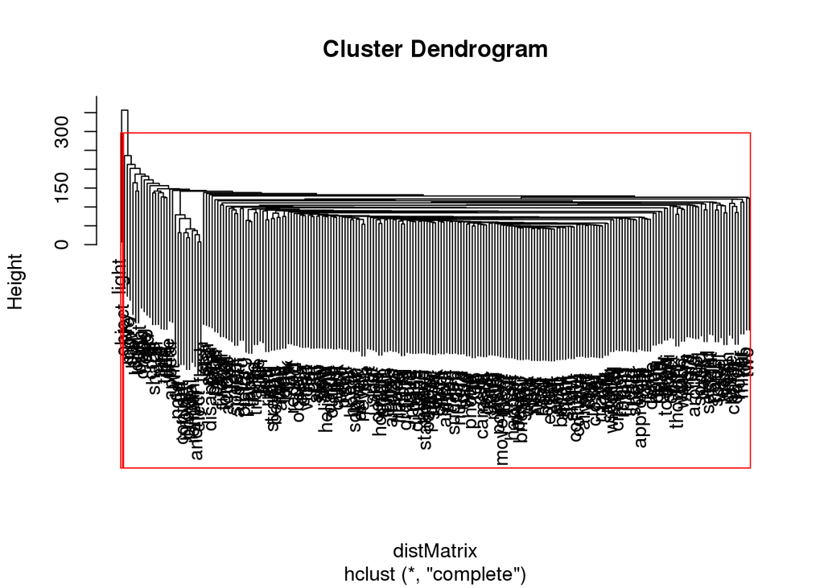

- ¿Con características sociales?  
  Utilizando la base de datos GDELT, se realiza un concentrado de eventos entre 2013 y 2015 como se vio en los graficos anteriores, estas consultas se realiza sobre protestas.

Podemos observar que el mayor numero de protestas se dio en el mes de Diciembre en US, y los avistamientos fueron mayores en Julio. Por lo que podriamos pensar, que es posible que no habia tantos UFOS mirando protestas como los juegos artificiales del 4 de Julio. :P

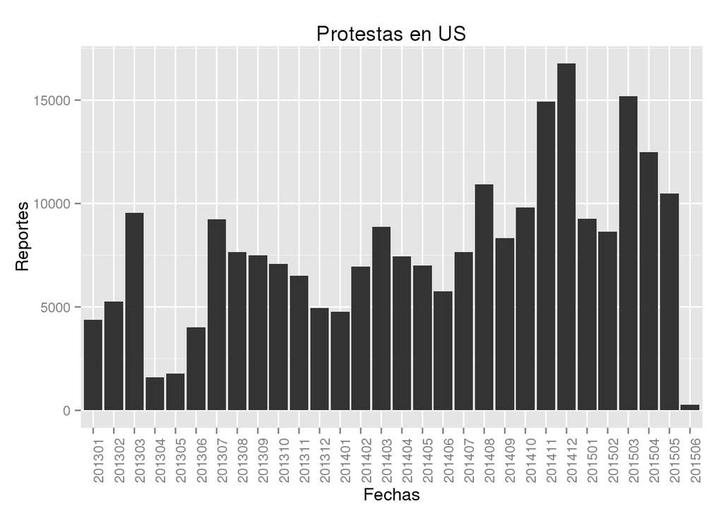

[figure not shown]